# 1. Clustering

## (a) $\mu_k$ and minimizing distortion function

$$J = \sum_{n}^{N}\sum_{k}^{K}r_{nk}||x_n-\mu_k||^2$$

In order to minimize the distortion function $J$ above, we must first take the derivative.

$$\frac{\partial J}{\partial \mu_k} = -2 \sum_{n}^{N}r_{nk}(x_n - \mu_k)$$

Setting the derivative with respect to $\mu_k$ to zero gives us a minimum or maximum.

$$\begin{align} -2 \sum_{n}^{N}r_{nk}(x_n - \mu_k) & = 0 \\ \sum_{n}^{N}r_{nk}(x_n - \mu_k) & = 0 \\ \sum_{n}^{N}r_{nk}x_n - \sum_{n}^{N}r_{nk}\mu_k & = 0 \\ \sum_{n}^{N}r_{nk}x_n & = ( \sum_{n}^{N}r_{nk} )\mu_k \\ & \Rightarrow \mu_k = \frac{\sum_{n}^{N}r_{nk}x_n}{\sum_{n}^{N}r_{nk}} \end{align}$$

In order to establish that this comes from a minimum, we would take the second derivative of the distortion function:

$$\begin{align} \frac{\partial^2 J}{\partial \mu_k^2} & = \frac{\partial}{\partial \mu_k} \left[ -2\sum_{n}^{N}r_{nk}(x_n-\mu_k) \right] \\ & = \frac{\partial}{\partial \mu_k} \left[ 2\sum_{n}^{N}r_{nk}(\mu_k-x_n) \right] \\ & = 2\sum_{n}^{N}r_{nk} \end{align}$$

which is positive (since $r_{nk}$ is the cluster assignment function), indicating that this is a minimum rather than a maximum.

## (b) Convergence to local optimum

After initialization, the k-means algorithm repeats two steps:

1. Assign each point $x_n$ to a cluster (defined by centroid $\mu_k$) using $argmin$
2. Recalculate centroids $\mu_k$ as the mean of all points in the cluster: $\frac{\sum_{n}^{N}r_{nk}x_n}{\sum_{n}^{N}r_{nk}} $

Step 1 means that the objective function (distance/dissimilarity from the centroid) will decrease or remain the same (but not increase), since cluster assignment is directly based on the centroid with the smallest distance from each point. In order to assign a point to a new cluster, the objective must be lower than that of the existing (previous) assignment.

Step 2 will decrease the objective function's value, since it will reduce the sum-of-squares distance within each cluster by recalculating the centroid based only on its assigned points.

Therefore, the value of the distortion function $J$ monotonically decreases as part of the algorithm. In addition, because it uses squared distance, it is bounded below by 0 (no real number squared can be less than 0). A monotonically decreasing function with a lower bound must converge. **Therefore, the algorithm converges.**

The end result of the partition are cluster assignments. Because there are a finite number of points ($N$) and a finite number of clusters ($K$), there must be a finite number of possible results ($K^N$). **Therefore, the algorithm must converge in a finite number of steps.**

## (c) Comparing distance metrics

**Single linkage** will successfully separate the two moon shapes when performing hierarchical (agglomerative) clustering. The primary reason is that the individual points within each moon are **densely packed**. Using single linkage, clusters are combined based on the shortest pairwise distance between elements of each cluster. Because the points are densely packed, single linkage will tend to select the nearby clusters within each moon, as any other cluster *within the same moon* will have a smaller distance metric than any cluster within the other moon.

Using complete linkage, the tips of each moon will be merged into the other moon's cluster. If one moon's tip forms its own cluster, the maximum distance between any point in the tip cluster and any point in the rest of its moon will be greater than the maximum distance between any point in the tip cluster and any point in the *other* moon, which is partially enclosing the tip. Therefore, using complete linkage will not separate the two shapes.

Using average linkage, one moon's tip may also be merged into the other moon's cluster. This is also the result of the partial enclosure of the tip by the other moon; encloser reduces the average distance from the tip to the rest of the other cluster.

# 2. Image compression using clustering

All examples below use the following image (also saved as `image.bmp` in the submitted .zip archive).

[figure not shown]

Code for implementation of K-medoids and K-means algorithms is included in `homework1_code.ipynb` in the submitted .zip archive.

## K-medoids

### K-medoids implementation

#### Summary

My implementation of K-medoids has three primary features:

1. Compression of the input matrix using NumPy's `unique` function
2. Iteration using a generator function (`yield` keyword) to reduce memory usage
3. Fast calculation of the distance matrix using SciPy's `cdist` function

Details of the algorithm are described below.

#### 1. Initialize medoids

I initiate medoids by reducing the input data array to its unique members (rows) and selecting `K` random points.

#### 2. Calculate dissimilarity (cost of current medoids)

Within each iteration of the algorithm, the distance of each pixel to each medoid is calculated in the form of a distance matrix using SciPy's `cdist` function.

`cdist` accepts a `metric` argument, which is used to run my code using different distance metrics: Euclidean or squared Euclidean.

#### 3. Assign cluster labels

Given a distance matrix, I determine each pixel's cluster assignment using NumPy's `argmin` function. This returns the index of the column with the lowest value - i.e. the lowest distance from each pixel.

#### 4. Update medoids

I iterate through each cluster, updating one medoid at a time.

For each medoid:

1. Isolate the pixels associated with its cluster using Boolean index slicing, generating a NumPy array
2. Compress the array using `unique`, which returns the array of unique pixels as well as an array of counts, indicating how many occurrences there are for each pixel
3. Calculate the cost of the current configuration: mean distance from medoid $k$ to all other points in the cluster
4. Iterate through all pixels within the cluster in chunks of 5,000 pixels; for each:
   1. Use `cdist` to calculate a distance matrix for each pixel in the current chunk to all pixels in the cluster
   2. Take the mean within-cluster pairwise distance for each pixel in the chunk
   3. Identify the lowest cost (lowest mean within-cluster pairwise distance) and the pixel with the lowest cost
   4. Compare the lowest cost to the current cost; if the lowest cost is less than the current cost, **update the medoid**

The `cdist` function has better performance than looping for calculating the distance matrix; however, it can be very memory intensive, as it creates the entire matrix. Iterating in chunks allows use of this function while avoiding memory errors.

#### 5. Check for convergence

If the medoids have not changed after step 4, then the algorithm has converged, and I run no more iterations.

If the medoids were updated, repeat the process.

### Results from testing different values of K

A table of results is displayed below.

| Metric | K | Iterations | Duration (Seconds) |
| --- | --- | --- | --- |
| Euclidean | 2 | 9 | 163.9 |
| Euclidean | 3 | 17 | 247.7 |
| Euclidean | 5 | 16 | 138.8 |
| Euclidean | 10 | 10 | 38.6 |
| Euclidean | 25 | 20 | 30.0 |
| Euclidean | 100 | 14 | 6.8 |
| Squared Euclidean | 2 | 4 | 58.0 |
| Squared Euclidean | 3 | 10 | 107.9 |
| Squared Euclidean | 5 | 8 | 55.5 |
| Squared Euclidean | 10 | 16 | 52.6 |
| Squared Euclidean | 25 | 24 | 31.8 |
| Squared Euclidean | 100 | 12 | 5.0 |

Based on those test results, it does not appear that there is a linear relationship between the value of $K$ and the number of iterations required to converge.

However, increasing $K$ does generally appear to reduce the **time** required to converge. The exception is moving from $K$ = 2 to $K$ = 3; $K$ = 3 takes the longest time to converge.

I also observed that using Euclidean distance took longer to converge. I attempted to use Minkowski distance, but the algorithm exceeded acceptable run times (over 800 seconds).

### Results from testing different starting medoids

To test the effect of different starting medoids, I specified $K$ = 10 and the following medoids:

```
[0,0,0],
[25, 25, 25],
[50, 50, 50],
[75, 75, 75],
[100, 100, 100],
[125, 125, 125],
[150, 150, 150],
[175, 175, 175],
[200, 200, 200],
[225, 225, 225]
```

My K-medoids function returns a set of cluster labels, which I used to reconstruct the image, replacing each pixel's actual RGB values with the RGB values of its assigned medoid.

I used my K-medoids function with and without starting medoids specified and compared the image reconstructed from the results of each.

Random Starting Medoids

Specified Starting Medoids

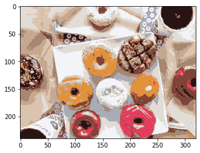

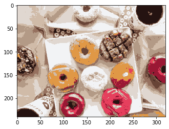

I observe a very slight visual difference; for example, the center-right donut has a stronger red color in the image resulting from specified starter medoids. I conclude that specifying initial medoids does affect the results, but the strength of the effect depends on the values of those medoids. The medoids I specified were evenly spread out through RGB space; a more skewed set of medoids might result in greater differences.

## K-means

### K-means implementation

#### 1. Initialize centroids

I initiate medoids by reducing the input data array to its unique members (rows) and selecting `K` random points. My K-means implementation calls the same initialization function used by my K-medoids implementation.

#### 2. Calculate dissimilarity

Within each iteration of the algorithm, the distance of each pixel to each centroid is calculated in the form of a distance matrix using SciPy's `cdist` function. For K-means, I use squared Euclidean distance.

#### 3. Assign cluster labels

Given a distance matrix, I determine each pixel's cluster assignment using NumPy's `argmin` function. This returns the index of the column with the lowest value - i.e. the lowest distance from each pixel. My K-means implementation calls the same cluster assignment function used by my K-medoids implementation.

#### 4. Update centroids

I iterate through each cluster, updating one centroid at a time.

For each centroid:

1. Isolate the set of pixels associated with the current cluster as a NumPy array using Boolean index slicing
2. Take the mean of those pixels
3. Replace the current medoid with the mean from step 2 using NumPy's `mean` function

#### 5. Check for convergence

If the centroids have not changed after step 4, then the algorithm has converged, and I run no more iterations.

If the centroids were updated, repeat the process.

### Results from testing different values of K

A table of results is displayed below.

| K | Iterations | Duration (Seconds) |
| --- | --- | --- |
| 2 | 19 | 0.13 |
| 3 | 32 | 0.22 |
| 5 | 101 | 0.8 |
| 10 | 67 | 0.85 |
| 25 | 100 | 2.42 |
| 100 | 161 | 13.04 |

Like K-medoids, there does not appear to be a linear relationship between $K$ and the number of iterations required to converge. Unlike K-medoids, my algorithm's run time **increases** as $K$ increases; however, the duration is consistently lower than durations required for K-medoids.

The lower run times required by K-means can be explained by the simpler update/swap step: instead of calculating a distance matrix for each pixel within the cluster, we simply take the mean.

The (observed) monotonically increasing duration can be explained by the algorithm's use of iteration to update centroids. As $K$ increases, so does the number of loop iterations required.

### Results from testing different starting centroids

To test the effect of different starting centroids, I specified $K$ = 10 and the following medoids:

```
[0,0,0],
[25, 25, 25],
[50, 50, 50],
[75, 75, 75],
[100, 100, 100],
[125, 125, 125],
[150, 150, 150],
[175, 175, 175],
[200, 200, 200],
[225, 225, 225]
```

My K-means function returns a set of cluster labels, which I used to reconstruct the image, replacing each pixel's actual RGB values with the RGB values of its assigned medoid.

I used my K-means function with and without starting centroids specified and compared the image reconstructed from the results of each.

Random Starting Centroids

Specified Starting Centroids

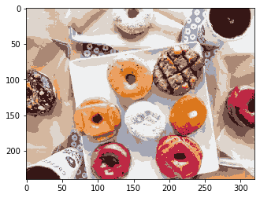

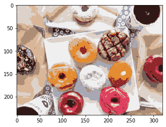

As with K-medoids, there is a noticeable difference - for example, the lower-right donut in the image generated from random starting centroids has a darker red color. However, as with K-medoids, the difference is fairly small.

I draw the same conclusion as I did with K-medoids: the initial cluster assignments affect the results, but the strength of the effect depends on the values of those assignments.

Logically, I would expect the effect of outliers to be stronger with K-means than with K-medoids, as the update step replaces the centroid with the mean of all within-cluster pixels - meaning that any outliers captured in the assignment step will cause the centroid to make a larger move.

# Comparing K-medoids and K-means

Both algorithms generate similar output quality. I observed no strong difference between the two. However, K-medoids consistently took longer than K-means to execute. As I observed earlier, this can be explained by the more complex update/swap step in K-medoids, which requires the comparison of each point to all other points within a cluster.